# LABOUR MARKET STATISTICS

### October 2020

##### **In June to August 2020, compared to March to May 2020 (the quarter before):** The **employment** rate was 73.9 per cent, higher than the quarter before (0.4 percentage points) and below the UK rate of 75.6 per cent. 2,635,000 people were in employment, 15,000 more than March to May 2020.

The **unemployment** rate was 4.5 per cent, the same as the quarter before (0 percentage points) and the same as the UK rate of 4.5 per cent. 124,000 people were unemployed, 1,000 more than March to May 2020.

The **inactivity** rate was 22.6 per cent, lower than the quarter before (0.4 percentage points) and above the UK rate of 20.8 per cent. 777,000 people were in economically inactive, 15,000 less than March to May 2020.

##### **Over the quarter**

From March to May 2020, the unemployment rate remained the same at 4.5 per cent, the employment rate increased to 73.9 per cent, and the inactivity rate decreased to 22.6 per cent.

##### **Over the year**

The unemployment rate increased, the employment rate decreased, and the inactivity rate increased.

##### **Compared with the UK**

Scotland’s unemployment rate was the same, the employment rate was lower and the inactivity rate was higher.

|  | Percentage Point Rate (per cent) | Percentage Point Change on quarter Mar-May 2020 | Percentage Point Change on year Jun-Aug 2019 |  | Level (thousands) Level (thousands) | Level (thousands) Change on quarter Mar-May 2020 | Level (thousands) Change on year Jun-Aug 2019 |
| --- | --- | --- | --- | --- | --- | --- | --- |
| Employment1 |  |  |  |  |  |  |  |
| Scotland | 73.9 | 0.4 | -0.4 |  | 2,635 | 15 | -1 |
| United Kingdom | 75.6 | -0.3 | -0.3 |  | 32,591 | -153 | -102 |
| Unemployment2 |  |  |  |  |  |  |  |
| Scotland | 4.5 | 0 | 0.4 |  | 124 | 1 | 12 |
| United Kingdom | 4.5 | 0.4 | 0.6 |  | 1,522 | 138 | 209 |
| Inactivity3 |  |  |  |  |  |  |  |
| Scotland | 22.6 | -0.4 | 0.1 |  | 777 | -15 | 4 |
| United Kingdom | 20.8 | 0 | -0.2 |  | 8,625 | -3 | -51 |

**Source:** Labour Force Survey, seasonally adjusted

Rates and change over time based on unrounded data.

Level:  
1,2: All persons aged 16+;  
3: All persons aged 16-64.

Denominator:  
1,3: all persons 16-64 years;  
2: economically active 16+.

##### **Employment Rate**

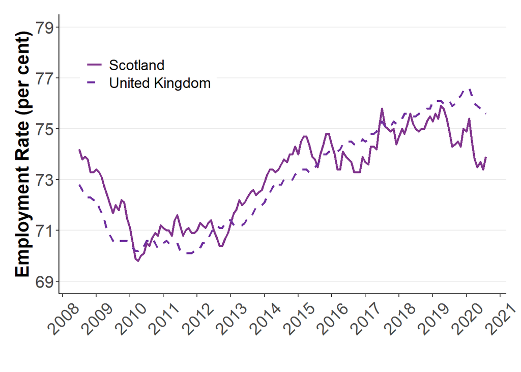

##### **Unemployment Rate**

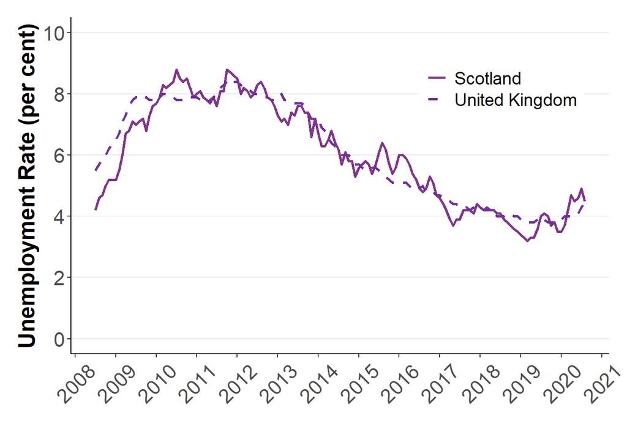

##### **Inactivity Rate**

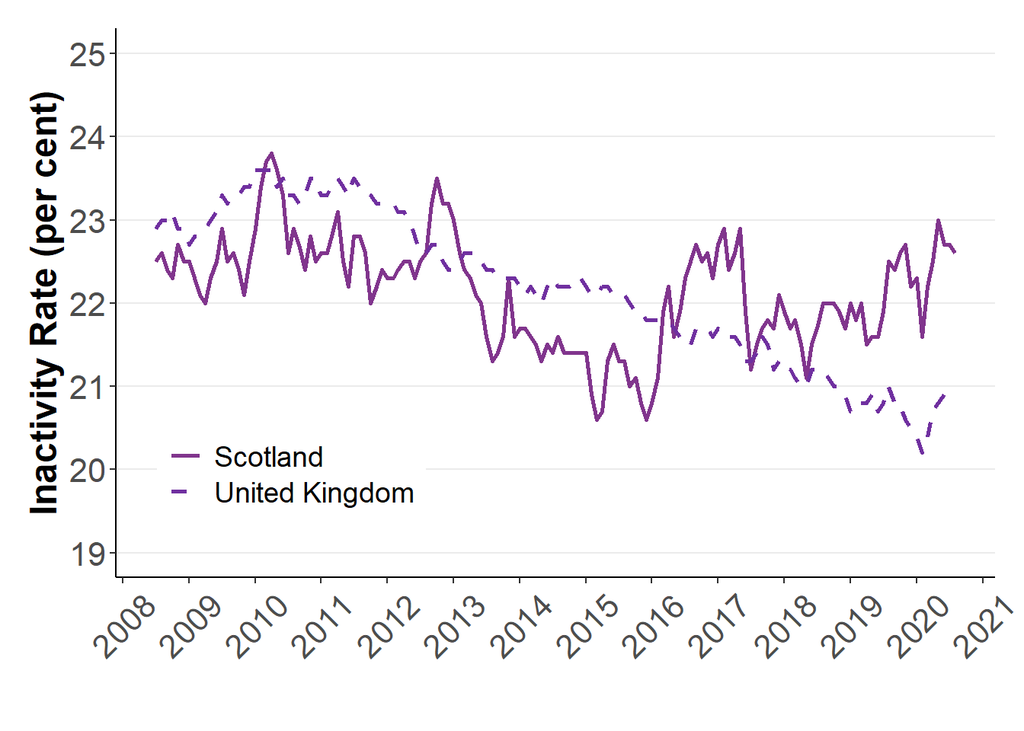

##### **Country/Region Comparisons**

Out of the 4 UK nations, Scotland has the joint 2nd highest unemployment, the 2nd highest employment rate, and the 2nd lowest inactivity rate.

Out of the 12 regions of the UK, Scotland has the 3th highest unemployment rate, 4th lowest employment rate, and the joint 4th highest inactivity rate.

|  |  | Employment |  | Unemployment |  | Inactivity |
| --- | --- | --- | --- | --- | --- | --- |
| England |  | 76 |  | 4 |  | 20 |
| Scotland |  | 74 |  | 4 |  | 23 |
| Wales |  | 73 |  | 4 |  | 24 |
| Northern Ireland |  | 71 |  | 4 |  | 27 |
| United Kingdom |  | 76 |  | 4 |  | 21 |

##### **Women (June to August 2020)** Scotland’s women’s employment rate is lower than the UK (71.2% v 72.1%), women’s unemployment rate is higher than the UK (4.4% v 4%) and women’s inactivity rate is higher than the UK (25.6% v 24.9%).

|  | Percentage Point Rate (per cent) | Percentage Point Change on quarter Mar-May 2020 | Percentage Point Change on year Jun-Aug 2019 |  | Level (thousands) Level (thousands) | Level (thousands) Change on quarter Mar-May 2020 | Level (thousands) Change on year Jun-Aug 2019 |
| --- | --- | --- | --- | --- | --- | --- | --- |
| Employment1 |  |  |  |  |  |  |  |
| Scotland | 71.2 | 0 | 0 |  | 1,294 | 1 | 11 |
| United Kingdom | 72.1 | -0.1 | 0.4 |  | 15,548 | -38 | 111 |
| Unemployment2 |  |  |  |  |  |  |  |
| Scotland | 4.4 | 0 | 0.8 |  | 59 | 0 | 11 |
| United Kingdom | 4 | 0.1 | 0.3 |  | 646 | 11 | 59 |
| Inactivity3 |  |  |  |  |  |  |  |
| Scotland | 25.6 | 0 | -0.6 |  | 450 | 0 | -11 |
| United Kingdom | 24.9 | 0 | -0.7 |  | 5,178 | 9 | -133 |

**Source:** Labour Force Survey, seasonally adjusted

Rates and change over time based on unrounded data.

Level:  
1,2: All persons aged 16+;  
3.:All persons aged 16-64.

Denominator:  
1,3: all persons 16-64 years;  
2: economically active 16+.

##### **Men (June to August 2020)** Scotland’s men’s employment rate is lower than the UK (76.7% v 79.1%), men’s unemployment rate is lower than the UK (4.6% v 4.9%) and men’s inactivity rate is higher than the UK (19.4% v 16.7%).

|  | Percentage Point Rate (per cent) | Percentage Point Change on quarter Mar-May 2020 | Percentage Point Change on year Jun-Aug 2019 |  | Level (thousands) Level (thousands) | Level (thousands) Change on quarter Mar-May 2020 | Level (thousands) Change on year Jun-Aug 2019 |
| --- | --- | --- | --- | --- | --- | --- | --- |
| Employment1 |  |  |  |  |  |  |  |
| Scotland | 76.7 | 0.8 | -0.9 |  | 1,341 | 14 | -11 |
| United Kingdom | 79.1 | -0.6 | -1.1 |  | 17,043 | -115 | -213 |
| Unemployment2 |  |  |  |  |  |  |  |
| Scotland | 4.6 | 0 | 0.1 |  | 65 | 1 | 1 |
| United Kingdom | 4.9 | 0.7 | 0.8 |  | 877 | 127 | 149 |
| Inactivity3 |  |  |  |  |  |  |  |
| Scotland | 19.4 | -0.9 | 0.9 |  | 327 | -15 | 15 |
| United Kingdom | 16.7 | -0.1 | 0.4 |  | 3,448 | -12 | 82 |

**Source:** Labour Force Survey, seasonally adjusted

Rates and change over time based on unrounded data.

Level:  
1,2: All persons aged 16+;  
3.:All persons aged 16-64.

Denominator:  
1,3: all persons 16-64 years;  
2: economically active 16+.

##### **About this Page** This page is updated monthly and summarises employment, unemployment and economic inactivity sourced from the Labour Force Survey for Scotland and the UK.

This release follows the ONS monthly releases of: [Regional Labour Market Statistics in the UK](https://www.ons.gov.uk/employmentandlabourmarket/peopleinwork/employmentandemployeetypes/bulletins/regionallabourmarket/previousReleases)

Further statistics relating to Scotland’s Labour Market can be found on the Scottish Government website: [Scottish Labour Market Statistics](https://www.gov.scot/collections/labour-market-statistics/)

**Sources of information**

All estimates are sourced from the labour force survey. The Labour Force Survey is a survey of households collected and published by the Office for Nationals Statistics. Information are obtained from a sample survey and are therefore subject to some error.